# People Analytics: Evaluating Factors Predictive of Resignation

Matheus Schmitz

[LinkedIn](https://www.linkedin.com/in/matheusschmitz/)

[Github Portfolio](https://matheus-schmitz.github.io/)

## Problem Statement

I've obtained a dataset from IBM containing various work-related features about a large number of employees, including a target feature `Attrition`, which assigns a employee to one of three classes {Current Employee, Terminated, Voluntary Resignation}.

Although a target feature does exist, my goal here is not to develop a Machine Learning model, but rather to perform People Analytics, using all the available features to extract insights which can then be used by the company's HR (Human Resources) department.

The dataset countains both information which was generated internal employee datasets and employee surveys on specific work-related manners, and it also contains certain information which related to the employees work history. The latter class is of especial interest to me, as those information could be used during the hiring process, to select employee's less likely to quit (Voluntary Resignation) or to be fired (Terminated).

The bulk of the work in this project will consist of Exploratory Analysis to extract insights, and Feature Selection, to uncover which are the most relevant attributes when it comes to predicting turnover.

**Dataset Source:** https://developer.ibm.com/patterns/data-science-life-cycle-in-action-to-solve-employee-attrition-problem/

**Data Encoding**

| **#** | **Education** | **EnvironmentSatisfaction** | **JobInvolvement** | **JobSatisfaction** | **PerformanceRating** | **RelationshipSatisfaction** | **WorkLifeBalance** |  |
| --- | --- | --- | --- | --- | --- | --- | --- | --- |
| 1 | Below College | Low | Low | Low | Low | Low | Bad |  |
| 2 | College | Medium | Medium | Medium | Good | Medium | Good |  |
| 3 | Bachelor | High | High | High | Excellent | High | Better |  |
| 4 | Master | Very High | Very High | Very High | Outstanding | Very High | Best |  |
| 5 | Doctor |  |  |  |  |  |  |  |

## Define Directory

```r
setwd("C:/Portfolio/People_Analytics_Resignations")
getwd()
```

'C:/Portfolio/People_Analytics_Resignations'

## Packages

```r
# Imports
library(caret)
library(ggplot2)
library(gridExtra)
library(dplyr)
library(tidyr)
library(data.table)
library(car)
library(caTools)
library(corrplot)
library(rpart)
library(rpart.plot)

# Set a smaller plot size
options(repr.plot.width=8, repr.plot.height=4)

# Align all titles to the middle of the plot
theme_update(plot.title = element_text(hjust = 0.5))
```

## Dataset

```r
# Load dataset from CSV file
data_hr <- fread('data/dataset.csv')
dim(data_hr)
```

1. 23058

2. 30

```r
head(data_hr)
```

| Age | Attrition | BusinessTravel | Department | DistanceFromHome | Education | EducationField | EnvironmentSatisfaction | Gender | JobInvolvement | ... | StockOptionLevel | TotalWorkingYears | TrainingTimesLastYear | WorkLifeBalance | YearsAtCompany | YearsInCurrentRole | YearsSinceLastPromotion | YearsWithCurrManager | Employee Source | AgeStartedWorking |
| --- | --- | --- | --- | --- | --- | --- | --- | --- | --- | --- | --- | --- | --- | --- | --- | --- | --- | --- | --- | --- |
| 41 | Voluntary Resignation | Travel_Rarely | Sales | 1 | 2 | Life Sciences | 2 | Female | 3 | ... | 0 | 8 | 0 | 1 | 6 | 4 | 0 | 5 | Referral | 33 |
| 37 | Voluntary Resignation | Travel_Rarely | Human Resources | 6 | 4 | Human Resources | 1 | Female | 3 | ... | 0 | 8 | 0 | 1 | 6 | 4 | 0 | 5 | Referral | 29 |
| 41 | Voluntary Resignation | Travel_Rarely | Sales | 1 | 2 | Life Sciences | 2 | Female | 3 | ... | 0 | 8 | 0 | 1 | 6 | 4 | 0 | 5 | Referral | 33 |
| 37 | Voluntary Resignation | Travel_Rarely | Human Resources | 6 | 4 | Marketing | 1 | Female | 3 | ... | 0 | 8 | 0 | 1 | 6 | 4 | 0 | 5 | Referral | 29 |
| 37 | Voluntary Resignation | Travel_Rarely | Human Resources | 6 | 4 | Human Resources | 1 | Female | 3 | ... | 0 | 8 | 0 | 1 | 6 | 4 | 0 | 5 | Referral | 29 |
| 37 | Voluntary Resignation | Travel_Rarely | Human Resources | 6 | 4 | Marketing | 1 | Female | 3 | ... | 0 | 8 | 0 | 1 | 6 | 4 | 0 | 5 | Referral | 29 |

```r
# Check variable types
str(data_hr)
```

```
Classes 'data.table' and 'data.frame':	23058 obs. of  30 variables:
 $ Age                     : int  41 37 41 37 37 37 41 41 41 41 ...
 $ Attrition               : chr  "Voluntary Resignation" "Voluntary Resignation" "Voluntary Resignation" "Voluntary Resignation" ...
 $ BusinessTravel          : chr  "Travel_Rarely" "Travel_Rarely" "Travel_Rarely" "Travel_Rarely" ...
 $ Department              : chr  "Sales" "Human Resources" "Sales" "Human Resources" ...
 $ DistanceFromHome        : int  1 6 1 6 6 6 1 1 1 1 ...
 $ Education               : int  2 4 2 4 4 4 2 2 2 2 ...
 $ EducationField          : chr  "Life Sciences" "Human Resources" "Life Sciences" "Marketing" ...
 $ EnvironmentSatisfaction : int  2 1 2 1 1 1 2 2 2 4 ...
 $ Gender                  : chr  "Female" "Female" "Female" "Female" ...
 $ JobInvolvement          : int  3 3 3 3 3 3 3 3 3 3 ...
 $ JobLevel                : int  2 2 2 2 2 2 2 2 2 4 ...
 $ JobRole                 : chr  "Sales Executive" "Sales Executive" "Sales Executive" "Sales Executive" ...
 $ JobSatisfaction         : int  4 4 4 4 4 4 4 4 4 3 ...
 $ MaritalStatus           : chr  "Single" "Single" "Single" "Single" ...
```

[output cut: 17 more lines]

```r
# Basic statistics on the variables
summary(data_hr)
```

```
      Age         Attrition         BusinessTravel      Department
 Min.   :18.00   Length:23058       Length:23058       Length:23058
 1st Qu.:30.00   Class :character   Class :character   Class :character
 Median :36.00   Mode  :character   Mode  :character   Mode  :character
 Mean   :37.04
 3rd Qu.:43.00
 Max.   :60.00
 DistanceFromHome   Education     EducationField     EnvironmentSatisfaction
 Min.   : 1.000   Min.   :1.000   Length:23058       Min.   :1.00
 1st Qu.: 2.000   1st Qu.:2.000   Class :character   1st Qu.:2.00
 Median : 7.000   Median :3.000   Mode  :character   Median :3.00
 Mean   : 9.215   Mean   :2.915                      Mean   :2.72
 3rd Qu.:14.000   3rd Qu.:4.000                      3rd Qu.:4.00
 Max.   :29.000   Max.   :5.000                      Max.   :4.00
    Gender          JobInvolvement    JobLevel       JobRole
 Length:23058       Min.   :1.00   Min.   :1.000   Length:23058
 Class :character   1st Qu.:2.00   1st Qu.:1.000   Class :character
 Mode  :character   Median :3.00   Median :2.000   Mode  :character
                    Mean   :2.73   Mean   :2.044
                    3rd Qu.:3.00   3rd Qu.:3.000
                    Max.   :4.00   Max.   :5.000
 JobSatisfaction MaritalStatus      MonthlyIncome   NumCompaniesWorked
 Min.   :1.000   Length:23058       Min.   : 1009   Min.   :0.000
 1st Qu.:2.000   Class :character   1st Qu.: 2900   1st Qu.:1.000
 Median :3.000   Mode  :character   Median : 4898   Median :2.000
 Mean   :2.725                      Mean   : 6416   Mean   :2.691
 3rd Qu.:4.000                      3rd Qu.: 8120   3rd Qu.:4.000
 Max.   :4.000                      Max.   :19999   Max.   :9.000
   OverTime         PercentSalaryHike PerformanceRating
 Length:23058       Min.   :11.00     Min.   :3.000
 Class :character   1st Qu.:12.00     1st Qu.:3.000
 Mode  :character   Median :14.00     Median :3.000
                    Mean   :15.22     Mean   :3.155
                    3rd Qu.:18.00     3rd Qu.:3.000
                    Max.   :25.00     Max.   :4.000
 RelationshipSatisfaction StockOptionLevel TotalWorkingYears
 Min.   :1.000            Min.   :0.0000   Min.   : 0.00
 1st Qu.:2.000            1st Qu.:0.0000   1st Qu.: 6.00
 Median :3.000            Median :1.0000   Median :10.00
 Mean   :2.713            Mean   :0.7944   Mean   :11.07
```

[output cut: 8 more lines]

```
 Max.   :6.000         Max.   :4.000   Max.   :40.00   Max.   :18.000
 YearsSinceLastPromotion YearsWithCurrManager Employee Source
 Min.   : 0.000          Min.   : 0.000       Length:23058
 1st Qu.: 0.000          1st Qu.: 2.000       Class :character
 Median : 1.000          Median : 3.000       Mode  :character
 Mean   : 2.164          Mean   : 4.091
 3rd Qu.: 3.000          3rd Qu.: 7.000
 Max.   :15.000          Max.   :17.000
 AgeStartedWorking
 Min.   : 0.00
 1st Qu.:20.00
 Median :25.00
 Mean   :25.96
 3rd Qu.:31.00
 Max.   :60.00
```

## Data Cleaning

```r
# Converting categorical variables to factor
data_hr$Attrition                <- as.factor(data_hr$Attrition)
data_hr$BusinessTravel           <- as.factor(data_hr$BusinessTravel)
data_hr$Department               <- as.factor(data_hr$Department)
data_hr$Education                <- as.factor(data_hr$Education)
data_hr$EducationField           <- as.factor(data_hr$EducationField)
data_hr$'Employee Source'        <- as.factor(data_hr$'Employee Source')
data_hr$EnvironmentSatisfaction  <- as.factor(data_hr$EnvironmentSatisfaction)
data_hr$Gender                   <- as.factor(data_hr$Gender)
data_hr$JobInvolvement           <- as.factor(data_hr$JobInvolvement)
data_hr$JobLevel                 <- as.factor(data_hr$JobLevel)
data_hr$JobRole                  <- as.factor(data_hr$JobRole)
data_hr$JobSatisfaction          <- as.factor(data_hr$JobSatisfaction)
data_hr$MaritalStatus            <- as.factor(data_hr$MaritalStatus)
data_hr$OverTime                 <- as.factor(data_hr$OverTime)
data_hr$PerformanceRating        <- as.factor(data_hr$PerformanceRating)
data_hr$RelationshipSatisfaction <- as.factor(data_hr$RelationshipSatisfaction)
data_hr$StockOptionLevel         <- as.factor(data_hr$StockOptionLevel)
data_hr$WorkLifeBalance          <- as.factor(data_hr$WorkLifeBalance)
```

```r
# Converting numerical variables to integer
data_hr$DistanceFromHome  <- as.integer(data_hr$DistanceFromHome)
data_hr$MonthlyIncome     <- as.integer(data_hr$MonthlyIncome)
data_hr$PercentSalaryHike <- as.integer(data_hr$PercentSalaryHike)
```

```r
# Drop any factor levels with a count of 0
data_hr <- droplevels(data_hr)
```

```r
# Check variable types
str(data_hr)
```

```
Classes 'data.table' and 'data.frame':	23058 obs. of  30 variables:
 $ Age                     : int  41 37 41 37 37 37 41 41 41 41 ...
 $ Attrition               : Factor w/ 3 levels "Current employee",..: 3 3 3 3 3 3 3 3 3 3 ...
 $ BusinessTravel          : Factor w/ 3 levels "Non-Travel","Travel_Frequently",..: 3 3 3 3 3 3 3 3 3 3 ...
 $ Department              : Factor w/ 3 levels "Human Resources",..: 3 1 3 1 1 1 3 3 3 3 ...
 $ DistanceFromHome        : int  1 6 1 6 6 6 1 1 1 1 ...
 $ Education               : Factor w/ 5 levels "1","2","3","4",..: 2 4 2 4 4 4 2 2 2 2 ...
 $ EducationField          : Factor w/ 6 levels "Human Resources",..: 2 1 2 3 1 3 2 2 2 2 ...
 $ EnvironmentSatisfaction : Factor w/ 4 levels "1","2","3","4": 2 1 2 1 1 1 2 2 2 4 ...
 $ Gender                  : Factor w/ 2 levels "Female","Male": 1 1 1 1 1 1 1 1 1 1 ...
 $ JobInvolvement          : Factor w/ 4 levels "1","2","3","4": 3 3 3 3 3 3 3 3 3 3 ...
 $ JobLevel                : Factor w/ 5 levels "1","2","3","4",..: 2 2 2 2 2 2 2 2 2 4 ...
 $ JobRole                 : Factor w/ 9 levels "Healthcare Representative",..: 8 8 8 8 8 8 8 8 8 4 ...
 $ JobSatisfaction         : Factor w/ 4 levels "1","2","3","4": 4 4 4 4 4 4 4 4 4 3 ...
 $ MaritalStatus           : Factor w/ 3 levels "Divorced","Married",..: 3 3 3 3 3 3 3 3 3 1 ...
```

[output cut: 17 more lines]

```r
# Fix the space in the `Employee Source` column name
names(data_hr)[names(data_hr) == "Employee Source"] <- "EmployeeSource"
```

## Feature Engineering

```r
# Creating a column with prior years of experience to better visualize an employee's experience profile
data_hr$PriorYearsOfExperience <- data_hr$TotalWorkingYears - data_hr$YearsAtCompany
dim(data_hr)
```

1. 23058

2. 31

```r
# Checking if I didn't break anything during feature engineering
summary(data_hr$PriorYearsOfExperience)
```

```
   Min. 1st Qu.  Median    Mean 3rd Qu.    Max.
  0.000   0.000   2.000   4.165   5.000  40.000
```

> A person's stability in a company (job tenure) is a mesure of the time an employee has been employed by it's current employer. An employee's job tenure history (how long the person stayed at each company) is highly important and often times is taken into account by recruiters when hiring a new employee.

```r
# Create a new feature (column) with each employee's average job tenure
data_hr$AverageTenure <- data_hr$PriorYearsOfExperience / data_hr$NumCompaniesWorked
dim(data_hr)
```

1. 23058

2. 32

```r
# Checking if I didn't break anything during feature engineering
summary(data_hr$AverageTenure)
```

```
   Min. 1st Qu.  Median    Mean 3rd Qu.    Max.    NA's
      0       0       1     Inf       4     Inf     372
```

> Seems like in this case I did break something. Checking back at the quartiles for the NumCompaniesWorked variable, I can see that some employees have a 0 in there, which means some rows got divided by zero, which resulted in those `infs`. I'll fix that by simply imputting 0 in place of the infs.

```r
# Fixing inf values on $AverageTenure
data_hr$AverageTenure[!is.finite(data_hr$AverageTenure)] <- 0
summary(data_hr$AverageTenure)
```

```
   Min. 1st Qu.  Median    Mean 3rd Qu.    Max.
 0.0000  0.0000  0.3333  1.7725  1.5000 40.0000
```

```r
# Create a filtered dataset that does not include terminations.
# I'm doing this because for this project I'm not as much looking into building ML models
# Instead I'm interested in which factors lead people to resign, and the datapoints for terminations won't help with that
# More likely than not they might just prove to mess with the analysis, so let's se apart a dataset without terminations
data_hr_1 <- data_hr[data_hr$Attrition != 'Termination']
data_hr_1 <- droplevels(data_hr_1)
dim(data_hr_1)
```

1. 22971

2. 32

## Exploratory Analysis

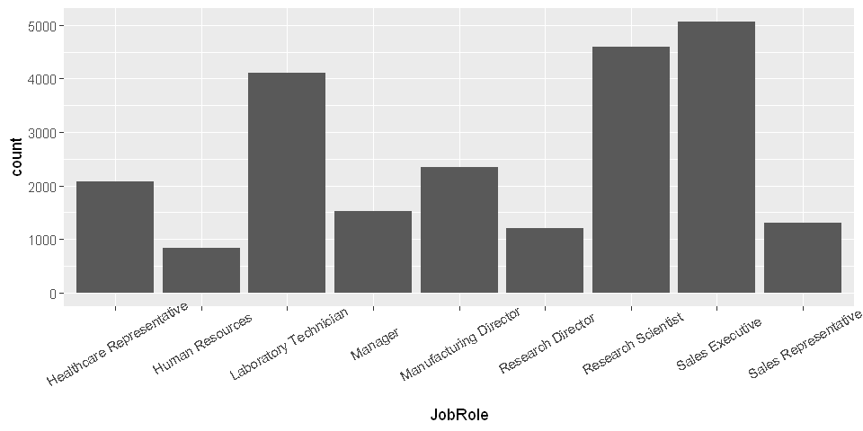

```r
# Job Role
ggplot(data_hr) +
    geom_bar(aes(x = JobRole)) +
    theme(axis.text.x = element_text(angle = 30, vjust = 0.7))
```

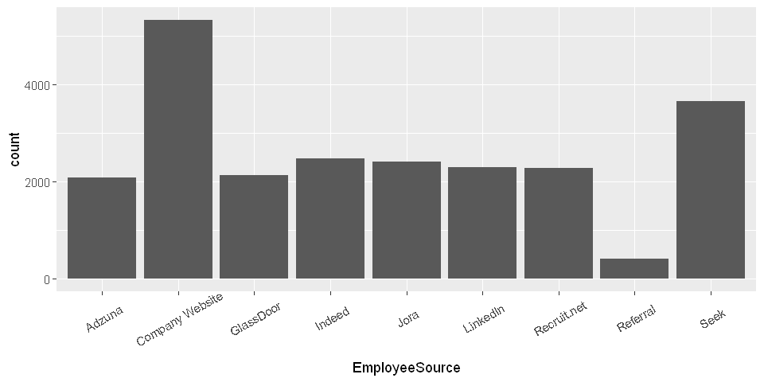

```r
# Employee Source
ggplot(data_hr) +
    geom_bar(aes(x = EmployeeSource)) +
    theme(axis.text.x = element_text(angle = 30, vjust = 0.7))
```

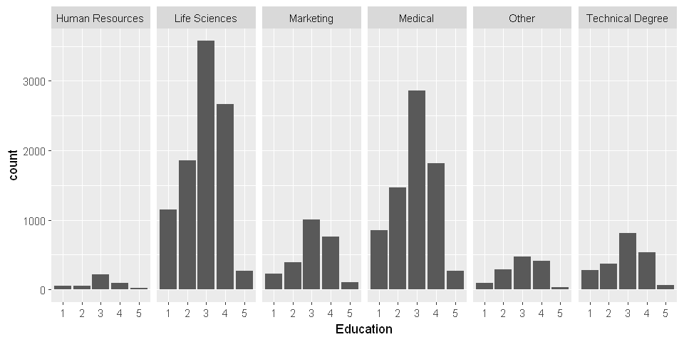

```r
# Education
# 1 is the lowest
ggplot(data_hr) +
    geom_bar(aes(x = Education)) +
    facet_grid(~EducationField)
```

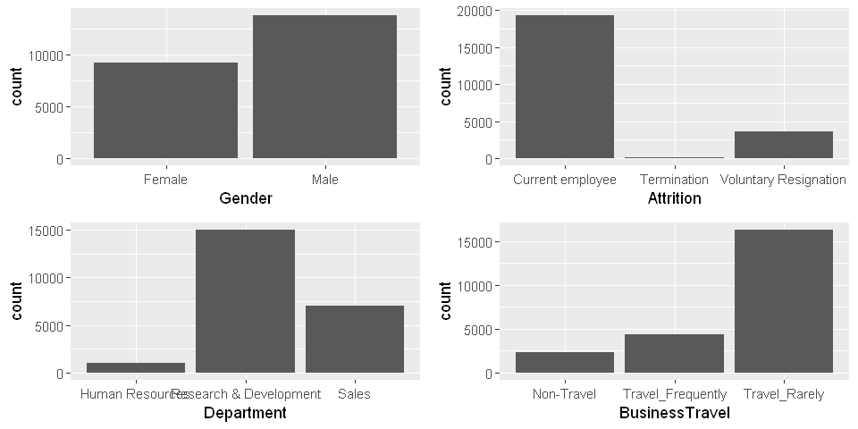

```r
# For the datapoints with few categories a Multiplot Grid can be used
p1 <- ggplot(data_hr) + geom_bar(aes(x = Gender))
p2 <- ggplot(data_hr) + geom_bar(aes(x = Attrition))
p3 <- ggplot(data_hr) + geom_bar(aes(x = Department))
p4 <- ggplot(data_hr) + geom_bar(aes(x = BusinessTravel))

# Organize the grid
grid.arrange(p1, p2, p3, p4, nrow=2, ncol=2)
```

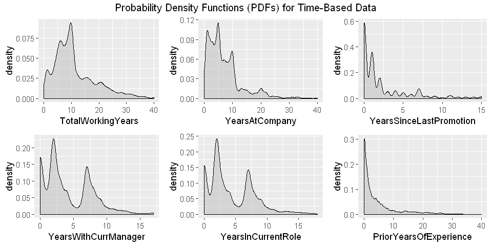

```r
# Probability Density Functions (PDFs) for Time-Based Data
p.TotalWorkingYears       <- ggplot(data_hr) + geom_density(aes(TotalWorkingYears), fill="gray", alpha=0.5)
p.YearsAtCompany          <- ggplot(data_hr) + geom_density(aes(YearsAtCompany), fill="gray", alpha=0.5)
p.YearsSinceLastPromotion <- ggplot(data_hr) + geom_density(aes(YearsSinceLastPromotion), fill="gray", alpha=0.5)
p.YearsWithCurrManager    <- ggplot(data_hr) + geom_density(aes(YearsWithCurrManager), fill="gray", alpha=0.5)
p.YearsInCurrentRole      <- ggplot(data_hr) + geom_density(aes(YearsInCurrentRole), fill="gray", alpha=0.5)
p.PriorYearsOfExperience  <- ggplot(data_hr) + geom_density(aes(PriorYearsOfExperience), fill="gray", alpha=0.5)

# Organize the grid
grid.arrange(p.TotalWorkingYears,
             p.YearsAtCompany,
             p.YearsSinceLastPromotion,
             p.YearsWithCurrManager,
             p.YearsInCurrentRole,
             p.PriorYearsOfExperience,
             nrow = 2,
             ncol = 3,
             top = "Probability Density Functions (PDFs) for Time-Based Data")
```

### Prior Work Experience & Age

```r
# Share of employees with X prior years of experience
less1  <- length(which(data_hr$PriorYearsOfExperience < 1)) / length(data_hr$PriorYearsOfExperience)
less3  <- length(which(data_hr$PriorYearsOfExperience < 3)) / length(data_hr$PriorYearsOfExperience)
less5  <- length(which(data_hr$PriorYearsOfExperience < 5)) / length(data_hr$PriorYearsOfExperience)
less7  <- length(which(data_hr$PriorYearsOfExperience < 7)) / length(data_hr$PriorYearsOfExperience)
less10 <- length(which(data_hr$PriorYearsOfExperience < 10)) / length(data_hr$PriorYearsOfExperience)

cat('Share of employees with less than 1 year of experience: ', less1*100,'%', '\n')
cat('Share of employees with less than 3 years of experience: ', less3*100,'%', '\n')
cat('Share of employees with less than 5 years of experience: ', less5*100,'%', '\n')
cat('Share of employees with less than 7 years of experience: ', less7*100,'%', '\n')
cat('Share of employees with less than 10 years of experience: ', less10*100,'%', '\n')
```

```
Share of employees with less than 1 year of experience:  32.46596 %
Share of employees with less than 3 years of experience:  58.28346 %
Share of employees with less than 5 years of experience:  70.85177 %
Share of employees with less than 7 years of experience:  79.52121 %
Share of employees with less than 10 years of experience:  85.89644 %
```

> 58% of the employees have under 3 years of work experience before joining IBM.

> Possible problems: young workforce, underdeveloped skillsets, less mature work mentality.

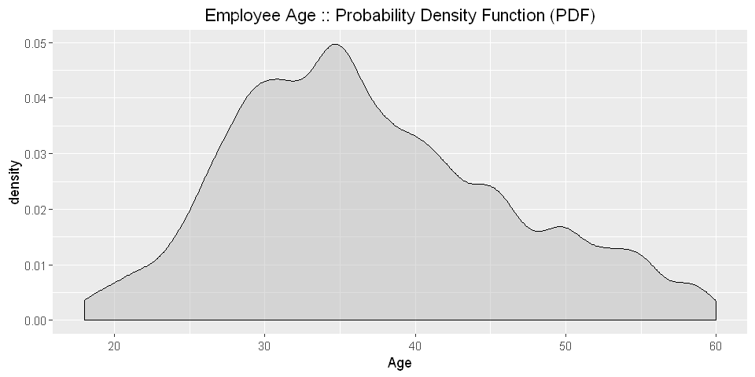

```r
# Checking how young the workforce really is
ggplot(data_hr) +
    geom_density(aes(x = Age), fill="gray", alpha=0.5) +
    ggtitle("Employee Age :: Probability Density Function (PDF)")
```

```r
# Share under 30
under30 = length(which(data_hr$Age < 30)) / length(data_hr$Age)

cat('Share of employees under 30 years old: ', under30*100,'%', '\n')
```

```
Share of employees under 30 years old:  21.65409 %
```

> Only 22% of the employees are under 30 years old. Turns out the employee base isn't as young as I had assumed!

### Education

```r
# Education
summary(data_hr$Education)
```

**1**

2659

**2**

4436

**3**

8930

**4**

6279

**5**

754

**Data Encoding**

| **#** | **Education** | **EnvironmentSatisfaction** | **JobInvolvement** | **JobSatisfaction** | **PerformanceRating** | **RelationshipSatisfaction** | **WorkLifeBalance** |  |
| --- | --- | --- | --- | --- | --- | --- | --- | --- |
| 1 | Below College | Low | Low | Low | Low | Low | Bad |  |
| 2 | College | Medium | Medium | Medium | Good | Medium | Good |  |
| 3 | Bachelor | High | High | High | Excellent | High | Better |  |
| 4 | Master | Very High | Very High | Very High | Outstanding | Very High | Best |  |
| 5 | Doctor |  |  |  |  |  |  |  |

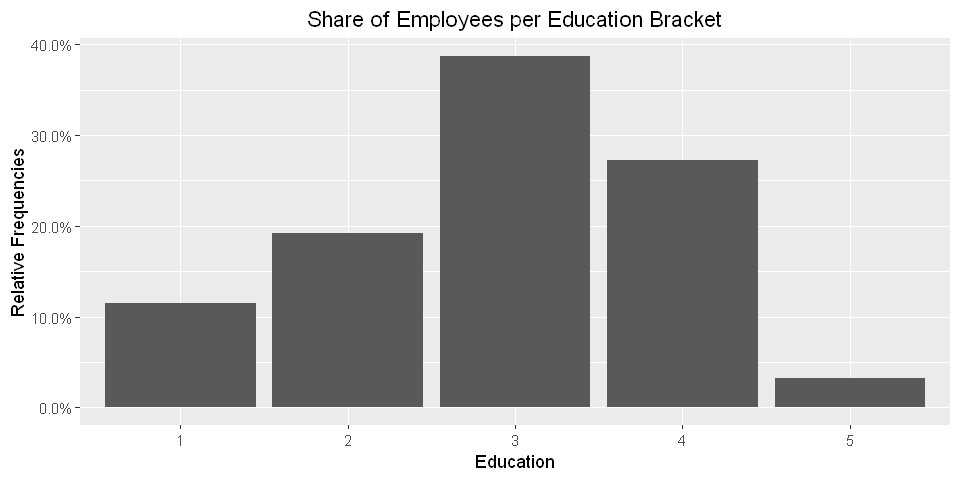

```r
# Education
ggplot(data_hr, aes(x = Education)) +
    geom_bar(aes(y = (..count..)/sum(..count..))) +
    scale_y_continuous(labels=scales::percent) +
    ylab("Relative Frequencies") +
    ggtitle("Share of Employees per Education Bracket")
```

> IBM's workforce is well educated, with ~39% of employees having a bachelors degree, a further 27% having a masters degree and a further 3% having a doctors degree. That's about 69% of the workforce having university education.

> Especially interesting are the 30% of the workforce that posses some sort of advanced degree, thaty ought to be considerably above average in comparison to other companies.

### Monthly Income x Job Satisfaction

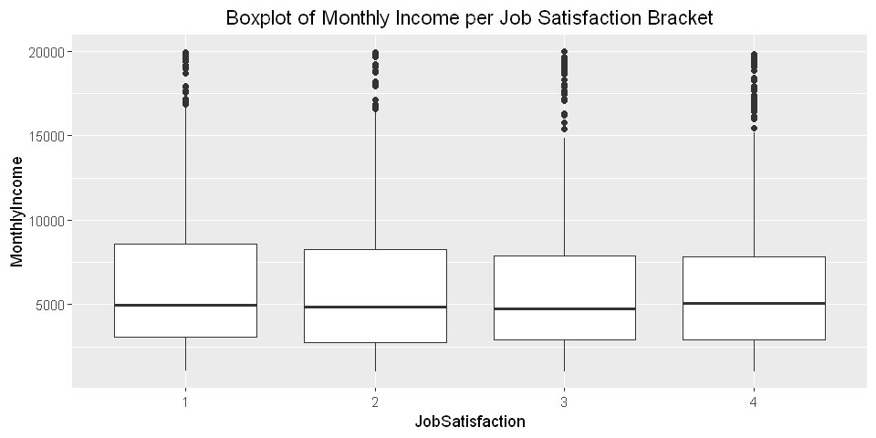

```r
# Boxplot with the monthly income distribution for each of the job satisfaction levels
ggplot(data = subset(data_hr, !is.na(JobSatisfaction)), aes(JobSatisfaction, MonthlyIncome)) +
    geom_boxplot() +
    ggtitle("Boxplot of Monthly Income per Job Satisfaction Bracket")
```

> Monthly income appears to have no effect on job satisfaction.

### Years at Company

```r
# How well do years at company correlate with other metrics?
yc1 <- cor(data_hr$YearsAtCompany, data_hr$TotalWorkingYears,       use = "complete.obs")
yc2 <- cor(data_hr$YearsAtCompany, data_hr$YearsInCurrentRole,      use = "complete.obs")
yc3 <- cor(data_hr$YearsAtCompany, data_hr$YearsSinceLastPromotion, use = "complete.obs")
yc4 <- cor(data_hr$YearsAtCompany, data_hr$YearsWithCurrManager,    use = "complete.obs")
yc5 <- cor(data_hr$YearsAtCompany, data_hr$MonthlyIncome,           use = "complete.obs")

cat('Correlation between YearsAtCompany and TotalWorkingYears:       ', yc1, '\n')
cat('Correlation between YearsAtCompany and YearsInCurrentRole:      ', yc2, '\n')
cat('Correlation between YearsAtCompany and YearsSinceLastPromotion: ', yc3, '\n')
cat('Correlation between YearsAtCompany and YearsWithCurrManager:    ', yc4, '\n')
cat('Correlation between YearsAtCompany and MonthlyIncome:           ', yc5, '\n')
```

```
Correlation between YearsAtCompany and TotalWorkingYears:        0.624816
Correlation between YearsAtCompany and YearsInCurrentRole:       0.7670497
Correlation between YearsAtCompany and YearsSinceLastPromotion:  0.6236737
Correlation between YearsAtCompany and YearsWithCurrManager:     0.7728072
Correlation between YearsAtCompany and MonthlyIncome:            0.4981578
```

> Not much surprise here - Analysing from the realistic perspective that people aren't going to be promoted every year, and that most often even with promotions people keep their roles and managers.

### Monthly Income

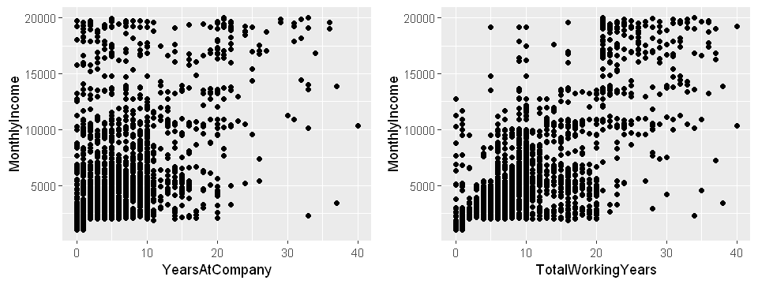

```r
# Scatterplot: YearsAtCompany x MonthlyIncome
# Scatterplot: TotalWorkingYears x MonthlyIncome
grid.arrange(ggplot(data_hr) + geom_point(aes(YearsAtCompany, MonthlyIncome)),
             ggplot(data_hr) + geom_point(aes(TotalWorkingYears, MonthlyIncome)),
             nrow = 1, ncol = 2)
```

> The fact the TotalWorkingYears is a better predictor of MonthlyIncome than YearsAtCompany just tells me that overall experience and expertise are more valuable (higher paid) than company loyalty.

### Monthly Income x Work Life Balance

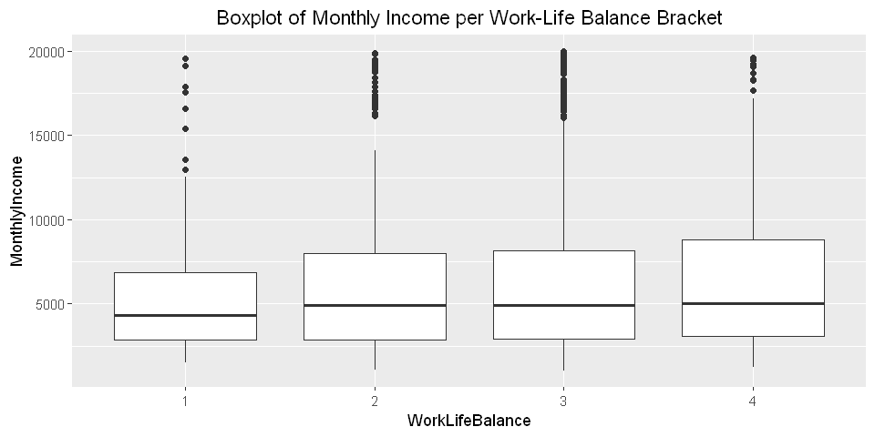

```r
ggplot(data = subset(data_hr, !is.na(WorkLifeBalance)), aes(WorkLifeBalance, MonthlyIncome)) +
    geom_boxplot() +
    ggtitle("Boxplot of Monthly Income per Work-Life Balance Bracket")
```

> Employees who rate their work-life balance poorly (rate 1) also have a lower monthly income.

> Poor work-life balance AND low income? That's a problem worth further investigations by IBM's HR!

### Gender Pay Gap

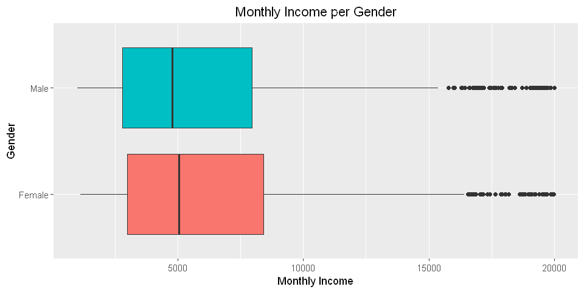

```r
ggplot(data = subset(data_hr, !is.na(Gender)), aes(Gender, MonthlyIncome, fill = Gender)) +
  geom_boxplot() +
  theme(legend.position = "none") +
  labs(x = "Gender", y = "Monthly Income", title = "Monthly Income per Gender") +
  coord_flip()
```

> There are no signs of gender discrimination in pay, with women earning slightly more than men.

### Gender Breakdown

```r
# Number of men and women overall
data_hr %>% count(Gender, sort = FALSE)
```

| Gender | n |
| --- | --- |
| Female | 9205 |
| Male | 13853 |

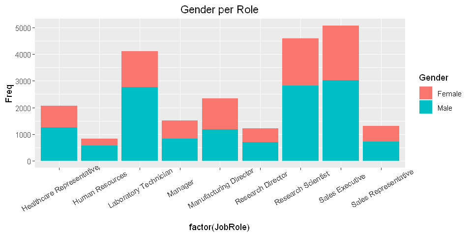

```r
# Men and women per role
tbl <- with(subset(data_hr, !is.na(JobRole)), table(JobRole, Gender))
ggplot(as.data.frame(tbl), aes(factor(JobRole), Freq, fill = Gender)) +
    geom_col(position = 'stack') +
    theme(axis.text.x = element_text(angle = 30, vjust = 0.7)) +
    ggtitle("Gender per Role")
```

```r
# Table breakdown of gender x role
data_hr %>% count(JobRole, Gender, sort = FALSE)
```

| JobRole | Gender | n |
| --- | --- | --- |
| Healthcare Representative | Female | 812 |
| Healthcare Representative | Male | 1257 |
| Human Resources | Female | 256 |
| Human Resources | Male | 577 |
| Laboratory Technician | Female | 1355 |
| Laboratory Technician | Male | 2757 |
| Manager | Female | 696 |
| Manager | Male | 825 |
| Manufacturing Director | Female | 1167 |
| Manufacturing Director | Male | 1179 |
| Research Director | Female | 503 |
| Research Director | Male | 709 |
| Research Scientist | Female | 1780 |
| Research Scientist | Male | 2811 |
| Sales Executive | Female | 2046 |
| Sales Executive | Male | 3021 |
| Sales Representative | Female | 590 |
| Sales Representative | Male | 717 |

### Job Role

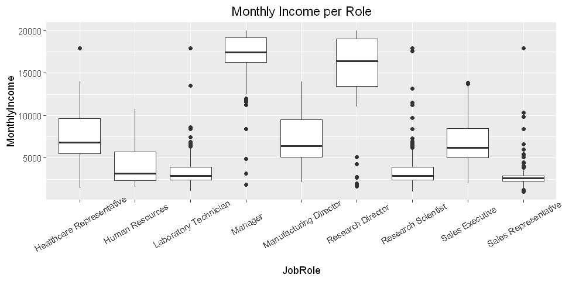

```r
ggplot(data = subset(data_hr, !is.na(JobRole))) +
    geom_boxplot(aes(JobRole, MonthlyIncome)) +
    theme(axis.text.x = element_text(angle = 30, vjust = 0.7)) +
    ggtitle("Monthly Income per Role")
```

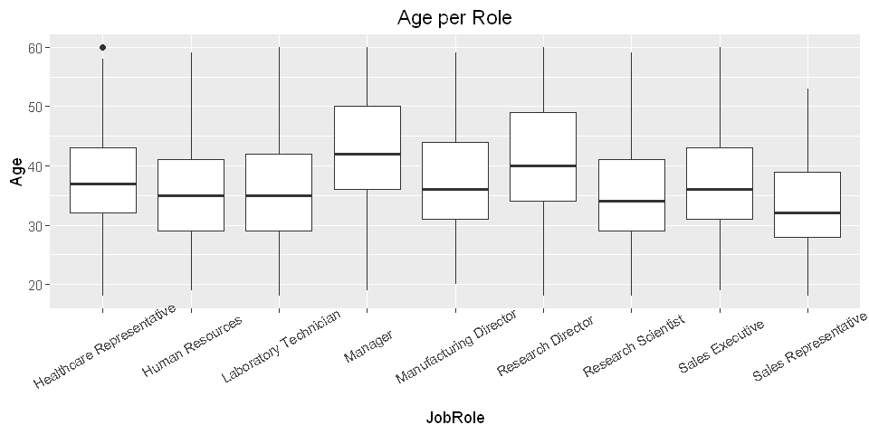

```r
ggplot(data = subset(data_hr, !is.na(JobRole))) +
    geom_boxplot(aes(JobRole, Age)) +
    theme(axis.text.x = element_text(angle = 30, vjust = 0.7)) +
    ggtitle("Age per Role")
```

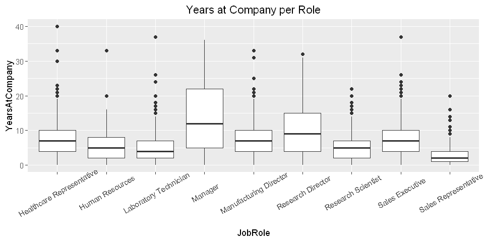

```r
ggplot(data = subset(data_hr, !is.na(JobRole))) +
    geom_boxplot(aes(JobRole, YearsAtCompany)) +
    theme(axis.text.x = element_text(angle = 30, vjust = 0.7)) +
    ggtitle("Years at Company per Role")
```

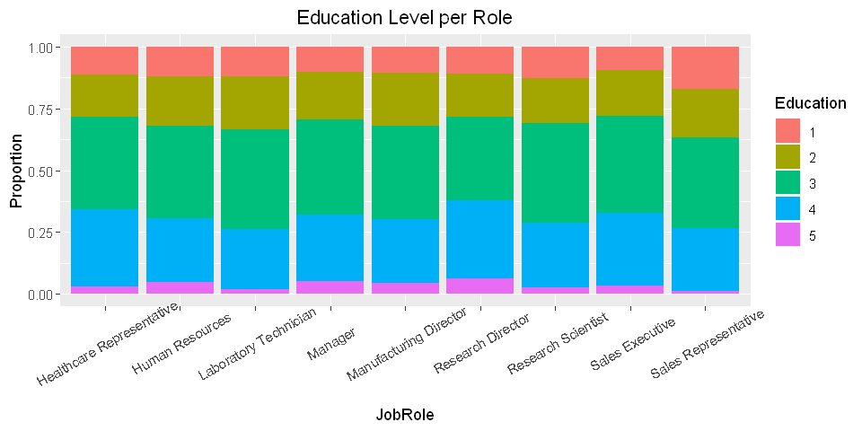

```r
ggplot(data = na.omit(data_hr)) +
    geom_bar(aes(JobRole, fill = Education), position = "fill") +
    theme(axis.text.x = element_text(angle = 30, vjust = 0.7)) +
    ggtitle("Education Level per Role") +
    ylab("Proportion")
```

### Resignations

> Note that here I'm using data_rh_1, which is the dataset without terminated employees.

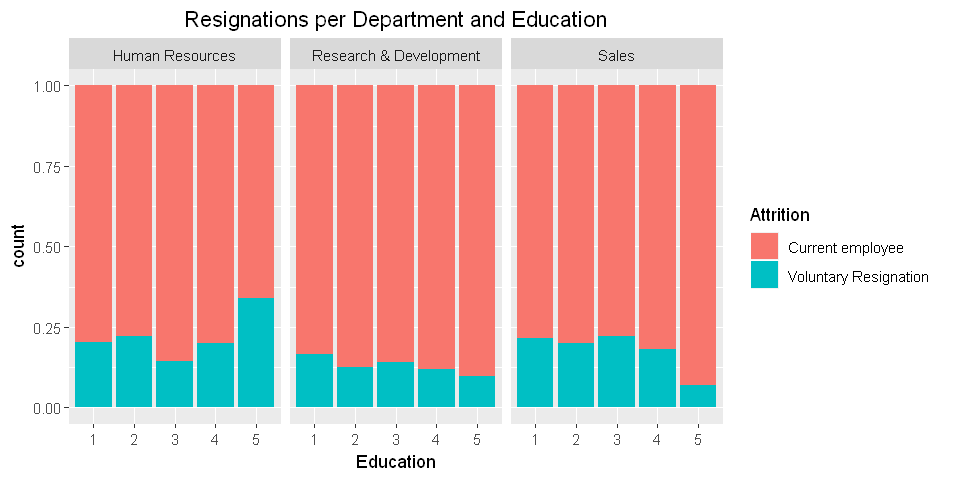

```r
ggplot(data = data_hr_1) +
    geom_bar(aes(x = Education , fill = Attrition), position = 'fill') +
    facet_grid(.~Department)  +
    ggtitle("Resignations per Department and Education")
```

> Funnily enough, HR staff seem to have the highest resignation rates... Perhaps they know something other employees don't?..

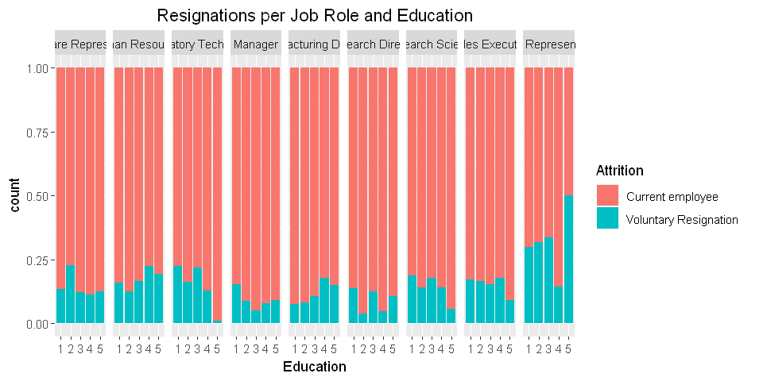

```r
ggplot(data = data_hr_1) +
    geom_bar(aes(x = Education , fill = Attrition), position = 'fill') +
    facet_grid(.~JobRole)  +
    ggtitle("Resignations per Job Role and Education")
```

> Unsurprisingly we see that managers and (research) directors are less prone to resignations, while we see that sales representatives are quite prone to resignations, which is not really surprising for anyone who has been in the job market and know that the profile of people working in those areas tends to be those always chasing a better deal.

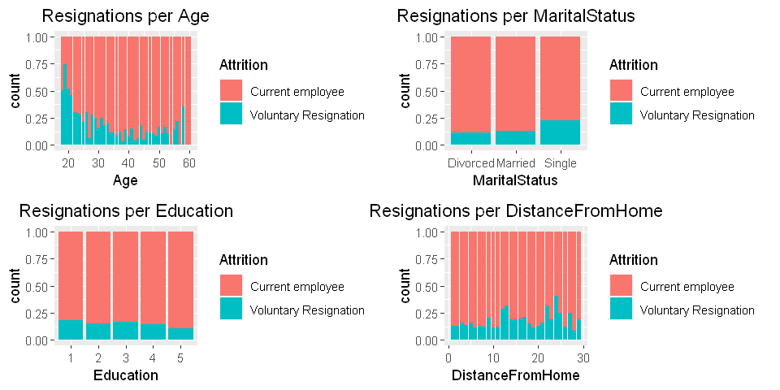

```r
# Analysis of variables frequently considered during the hiring process
p1 <- ggplot(data_hr_1) + geom_bar(aes(x = Age, fill = Attrition), position = 'fill') + ggtitle("Resignations per Age")
p2 <- ggplot(data_hr_1) + geom_bar(aes(x = MaritalStatus, fill = Attrition), position = 'fill') + ggtitle("Resignations per MaritalStatus")
p3 <- ggplot(data_hr_1) + geom_bar(aes(x = Education, fill = Attrition), position = 'fill') + ggtitle("Resignations per Education")
p4 <- ggplot(data_hr_1) + geom_bar(aes(x = DistanceFromHome, fill = Attrition), position = 'fill') + ggtitle("Resignations per DistanceFromHome")
grid.arrange(p1, p2, p3, p4, nrow=2, ncol=2)
```

> Looks like that at about the age people start having babies, they lose their appetite for resigning and seeking new opportunities...

> Also Single people are somewhat more likely to resign, as are those living further away from the company.

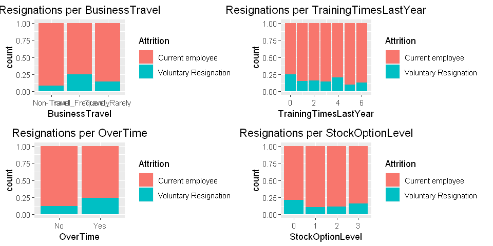

```r
# Analysis of variables measuring the "status" of a current employee
p1 <- ggplot(data_hr_1) + geom_bar(aes(x = BusinessTravel, fill = Attrition), position = 'fill') + ggtitle("Resignations per BusinessTravel")
p2 <- ggplot(data_hr_1) + geom_bar(aes(x = TrainingTimesLastYear, fill = Attrition), position = 'fill') + ggtitle("Resignations per TrainingTimesLastYear")
p3 <- ggplot(data_hr_1) + geom_bar(aes(x = OverTime, fill = Attrition), position = 'fill') + ggtitle("Resignations per OverTime")
p4 <- ggplot(data_hr_1) + geom_bar(aes(x = StockOptionLevel, fill = Attrition), position = 'fill') + ggtitle("Resignations per StockOptionLevel")
grid.arrange(p1, p2, p3, p4, nrow=2, ncol=2)
```

> When business travel and over time requirements make people more prone to resignations. Are those two correlated?

```r
# Co-Occurance of Business Travel and Over Time
data_hr %>% count(BusinessTravel, OverTime, sort = FALSE)
```

| BusinessTravel | OverTime | n |
| --- | --- | --- |
| Non-Travel | No | 1796 |
| Non-Travel | Yes | 548 |
| Travel_Frequently | No | 3054 |
| Travel_Frequently | Yes | 1324 |
| Travel_Rarely | No | 11674 |
| Travel_Rarely | Yes | 4662 |

> No correlation between BusinessTravel and OverTime. Seem that regardless of business travel status, about 1/3 of employee's report doing overtime.

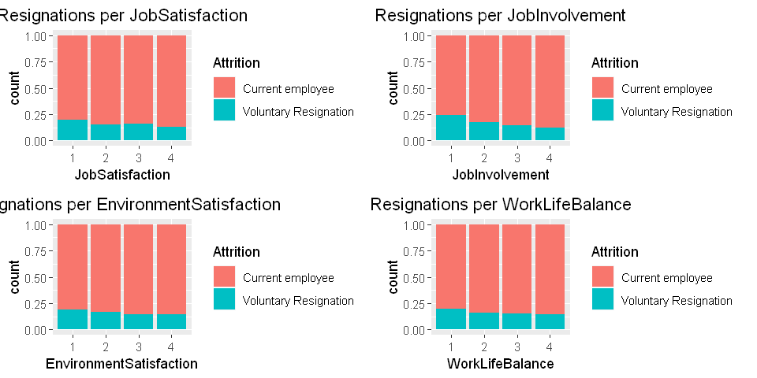

```r
# Analysis of variables measuring job satisfactions
p1 <- ggplot(data_hr_1) + geom_bar(aes(x = JobSatisfaction, fill = Attrition), position = 'fill') + ggtitle("Resignations per JobSatisfaction")
p2 <- ggplot(data_hr_1) + geom_bar(aes(x = JobInvolvement, fill = Attrition), position = 'fill') + ggtitle("Resignations per JobInvolvement")
p3 <- ggplot(data_hr_1) + geom_bar(aes(x = EnvironmentSatisfaction, fill = Attrition), position = 'fill') + ggtitle("Resignations per EnvironmentSatisfaction")
p4 <- ggplot(data_hr_1) + geom_bar(aes(x = WorkLifeBalance, fill = Attrition), position = 'fill') + ggtitle("Resignations per WorkLifeBalance")
grid.arrange(p1, p2, p3, p4, nrow=2, ncol=2)
```

> Again no surprises, less satisfaction and involment lead to more resignations. Same for worse work-life balance.

## Predictive Modeling

> Here the goal isn't to train the best possible algorithm to predict new data points, but rather to train understandable algorithms which would provide useful information to the Human Resources department. For this reason there will also be no train-test split.

> One of the main implicatios is that I will only be using variables which are known during the hiring process, as variables that only occur after hiring are useless for making hiring predictions.

```r
# Remebering all variables
head(data_hr, 3)
```

| Age | Attrition | BusinessTravel | Department | DistanceFromHome | Education | EducationField | EnvironmentSatisfaction | Gender | JobInvolvement | ... | TrainingTimesLastYear | WorkLifeBalance | YearsAtCompany | YearsInCurrentRole | YearsSinceLastPromotion | YearsWithCurrManager | EmployeeSource | AgeStartedWorking | PriorYearsOfExperience | AverageTenure |
| --- | --- | --- | --- | --- | --- | --- | --- | --- | --- | --- | --- | --- | --- | --- | --- | --- | --- | --- | --- | --- |
| 41 | Voluntary Resignation | Travel_Rarely | Sales | 1 | 2 | Life Sciences | 2 | Female | 3 | ... | 0 | 1 | 6 | 4 | 0 | 5 | Referral | 33 | 2 | 0.25 |
| 37 | Voluntary Resignation | Travel_Rarely | Human Resources | 6 | 4 | Human Resources | 1 | Female | 3 | ... | 0 | 1 | 6 | 4 | 0 | 5 | Referral | 29 | 2 | 0.25 |
| 41 | Voluntary Resignation | Travel_Rarely | Sales | 1 | 2 | Life Sciences | 2 | Female | 3 | ... | 0 | 1 | 6 | 4 | 0 | 5 | Referral | 33 | 2 | 0.50 |

### Logistic Regression

```r
# Logistic Regression Model (GLM) using variables available at hiring time
model_v1 <- glm(Attrition ~ Age + Department + DistanceFromHome + EmployeeSource +
                   JobRole + MaritalStatus + AverageTenure + PriorYearsOfExperience + Gender +
                   Education + EducationField,
                 family = binomial,
                 data = data_hr_1)
summary(model_v1)
```

```
Call:
glm(formula = Attrition ~ Age + Department + DistanceFromHome +
    EmployeeSource + JobRole + MaritalStatus + AverageTenure +
    PriorYearsOfExperience + Gender + Education + EducationField,
    family = binomial, data = data_hr_1)

Deviance Residuals:
    Min       1Q   Median       3Q      Max
-1.4484  -0.6177  -0.4918  -0.3558   2.7300

Coefficients:
                                  Estimate Std. Error z value Pr(>|z|)
(Intercept)                      -0.499751   0.199492  -2.505 0.012241 *
Age                              -0.044889   0.002446 -18.348  < 2e-16 ***
DepartmentResearch & Development -0.427955   0.103053  -4.153 3.28e-05 ***
DepartmentSales                   0.025684   0.106499   0.241 0.809423
DistanceFromHome                  0.020372   0.002522   8.076 6.69e-16 ***
EmployeeSourceCompany Website     0.183335   0.074868   2.449 0.014334 *
EmployeeSourceGlassDoor           0.006274   0.089680   0.070 0.944229
EmployeeSourceIndeed             -0.080908   0.089734  -0.902 0.367244
EmployeeSourceJora                0.183678   0.084958   2.162 0.030618 *
EmployeeSourceLinkedIn           -0.079145   0.090405  -0.875 0.381325
EmployeeSourceRecruit.net        -0.050665   0.089444  -0.566 0.571095
EmployeeSourceReferral            0.230121   0.147168   1.564 0.117897
EmployeeSourceSeek               -0.005837   0.079828  -0.073 0.941708
JobRoleHuman Resources            0.107348   0.125753   0.854 0.393302
JobRoleLaboratory Technician      0.314968   0.080707   3.903 9.52e-05 ***
JobRoleManager                   -0.402633   0.123788  -3.253 0.001144 **
JobRoleManufacturing Director    -0.083426   0.095273  -0.876 0.381221
JobRoleResearch Director         -0.292195   0.126243  -2.315 0.020637 *
JobRoleResearch Scientist         0.111877   0.079359   1.410 0.158608
JobRoleSales Executive           -0.028140   0.079873  -0.352 0.724611
JobRoleSales Representative       0.478077   0.096067   4.977 6.47e-07 ***
MaritalStatusMarried              0.176289   0.053865   3.273 0.001065 **
MaritalStatusSingle               0.747383   0.053896  13.867  < 2e-16 ***
AverageTenure                    -0.021245   0.009467  -2.244 0.024825 *
PriorYearsOfExperience            0.019787   0.005399   3.665 0.000248 ***
GenderMale                        0.030982   0.038752   0.800 0.424000
Education2                        0.067584   0.069195   0.977 0.328712
Education3                        0.092553   0.061236   1.511 0.130684
Education4                        0.071013   0.066760   1.064 0.287461
Education5                       -0.233758   0.134267  -1.741 0.081685 .
EducationFieldLife Sciences      -0.148858   0.143810  -1.035 0.300620
EducationFieldMarketing          -0.106268   0.152995  -0.695 0.487317
EducationFieldMedical            -0.202212   0.145203  -1.393 0.163736
EducationFieldOther              -0.137807   0.161652  -0.852 0.393940
EducationFieldTechnical Degree    0.180977   0.154552   1.171 0.241608
---
Signif. codes:  0 '***' 0.001 '**' 0.01 '*' 0.05 '.' 0.1 ' ' 1

(Dispersion parameter for binomial family taken to be 1)

    Null deviance: 19951  on 22970  degrees of freedom
Residual deviance: 18626  on 22936  degrees of freedom
AIC: 18696

Number of Fisher Scoring iterations: 5
```

> Seems like all education related variables (Education and EducationField) are not really significative (have high p-values) when it comes to predicting Attrition, so I'll remove them to make a simpler model.

```r
# Removing values with a high p-value (Education and EducationField)
model_v2 <- glm(Attrition ~ Age + Department + DistanceFromHome + EmployeeSource +
                   JobRole + MaritalStatus + AverageTenure + PriorYearsOfExperience + Gender,
                 family = binomial,
                 data = data_hr_1)
summary(model_v2)
```

```
Call:
glm(formula = Attrition ~ Age + Department + DistanceFromHome +
    EmployeeSource + JobRole + MaritalStatus + AverageTenure +
    PriorYearsOfExperience + Gender, family = binomial, data = data_hr_1)

Deviance Residuals:
    Min       1Q   Median       3Q      Max
-1.3428  -0.6201  -0.4941  -0.3619   2.7143

Coefficients:
                                  Estimate Std. Error z value Pr(>|z|)
(Intercept)                      -0.594443   0.163302  -3.640 0.000272 ***
Age                              -0.044338   0.002361 -18.781  < 2e-16 ***
DepartmentResearch & Development -0.455831   0.097648  -4.668 3.04e-06 ***
DepartmentSales                   0.006375   0.100798   0.063 0.949567
DistanceFromHome                  0.023945   0.002219  10.792  < 2e-16 ***
EmployeeSourceCompany Website     0.185836   0.074684   2.488 0.012835 *
EmployeeSourceGlassDoor           0.004131   0.089469   0.046 0.963174
EmployeeSourceIndeed             -0.084488   0.089587  -0.943 0.345638
EmployeeSourceJora                0.182141   0.084629   2.152 0.031378 *
EmployeeSourceLinkedIn           -0.073833   0.090249  -0.818 0.413300
EmployeeSourceRecruit.net        -0.058670   0.089241  -0.657 0.510903
EmployeeSourceReferral            0.237922   0.146800   1.621 0.105078
EmployeeSourceSeek               -0.006818   0.079571  -0.086 0.931717
JobRoleHuman Resources            0.099083   0.125594   0.789 0.430163
JobRoleLaboratory Technician      0.312339   0.080556   3.877 0.000106 ***
JobRoleManager                   -0.418085   0.123665  -3.381 0.000723 ***
JobRoleManufacturing Director    -0.079696   0.095061  -0.838 0.401826
JobRoleResearch Director         -0.308958   0.126075  -2.451 0.014263 *
JobRoleResearch Scientist         0.119993   0.079265   1.514 0.130071
JobRoleSales Executive           -0.023432   0.079774  -0.294 0.768961
JobRoleSales Representative       0.483836   0.095952   5.042 4.60e-07 ***
MaritalStatusMarried              0.176480   0.053793   3.281 0.001035 **
MaritalStatusSingle               0.747665   0.053772  13.904  < 2e-16 ***
AverageTenure                    -0.019906   0.009465  -2.103 0.035453 *
PriorYearsOfExperience            0.019187   0.005400   3.553 0.000381 ***
GenderMale                        0.033764   0.038690   0.873 0.382838
---
Signif. codes:  0 '***' 0.001 '**' 0.01 '*' 0.05 '.' 0.1 ' ' 1

(Dispersion parameter for binomial family taken to be 1)

    Null deviance: 19951  on 22970  degrees of freedom
Residual deviance: 18668  on 22945  degrees of freedom
AIC: 18720

Number of Fisher Scoring iterations: 5
```

> Variables that are significative predictors of STAYING: (negative coefficients)
> 1. Age
> 2. Department = Research & Development
> 3. JobRole = Manager
> 4. JobRole = Research Director
> 5. AverageTenure

>

> Variables that are significative predictors of LEAVING: (positive coefficients)
> 1. DistanceFromHome
> 2. EmployeeSource = Company Website
> 3. JobRole = Laboratory Technician
> 4. JobRole = Sales Representative
> 5. MaritalStatus = Married
> 6. MaritalStatus = Single
> 7. PriorYearsOfExperience

### Gradient Boosting with XGBoost

XGBoost documentation on Feature Selection: https://xgboost.readthedocs.io/en/latest/R-package/discoverYourData.html

```r
# Necessary packages
require(xgboost)
require(Matrix)
require(data.table)
library(correlationfunnel)
if (!require('vcd')) install.packages('vcd')
```

```r
# Create a binary target variable (required by XGBoost)

# Binarize the Attrition column
tmp <- data_hr_1 %>%
        select(Attrition) %>%
        binarize()

# Select the binary mapping where CurrentEmployee==0 and VoluntaryResignation==1
data_hr_1$Resigned <- tmp[2]

# Fix the data type of the new column (from list to numeric)
data_hr$Resigned  <- as.integer(data_hr$Resigned)

# Check result
str(data_hr_1$Resigned)
```

```
 num [1:22971] 1 1 1 1 1 1 1 1 1 1 ...
 - attr(*, "assign")= int [1:2] 1 1
 - attr(*, "contrasts")=List of 1
  ..$ Attrition: chr "contr.treatment"
```

```r
# Class distribution
data_hr_1 %>% count(Resigned, sort = FALSE)
```

| Resigned | n |
| --- | --- |
| 0 | 19370 |
| 1 | 3601 |

> As expected there is some inbalance, but if I recall the literature correctly, as long as the rare class is still ~20% the size of the common class, then one shouldn't expect many issues due to class balance.

```r
# Create an one-hot encoded sparse matrix needed for XGBOOST, using only the same variables as in model_v1
sparse_matrix <- sparse.model.matrix(Resigned ~ Age + Department + DistanceFromHome + EmployeeSource +
                                         JobRole + MaritalStatus + AverageTenure + PriorYearsOfExperience + Gender +
                                         Education + EducationField,
                                     data = data_hr_1)
head(sparse_matrix)
```

```
   [[ suppressing 35 column names '(Intercept)', 'Age', 'DepartmentResearch & Development' ... ]]
```

```
6 x 35 sparse Matrix of class "dgCMatrix"

1 1 41 . 1 1 . . . . . . 1 . . . . . . . 1 . . 1 0.25 2 . 1 . . . 1 . . . .
2 1 37 . . 6 . . . . . . 1 . . . . . . . 1 . . 1 0.25 2 . . . 1 . . . . . .
3 1 41 . 1 1 . . . . . . 1 . . . . . . . 1 . . 1 0.50 2 . 1 . . . 1 . . . .
4 1 37 . . 6 . . . . . . 1 . . . . . . . 1 . . 1 0.40 2 . . . 1 . . 1 . . .
5 1 37 . . 6 . . . . . . 1 . . . . . . . 1 . . 1 0.25 2 . . . 1 . . . . . .
6 1 37 . . 6 . . . . . . 1 . . . . . . . 1 . . 1 0.40 2 . . . 1 . . 1 . . .
```

```r
# Create a vector with the binzarized target label
output_vector <- data_hr_1[,Resigned]
head(output_vector)
```

1. 1

2. 1

3. 1

4. 1

5. 1

6. 1

```r
# Train model
bst <- xgboost(data = sparse_matrix, label = output_vector, max.depth = 6,
               eta = 0.3, nthread = -1, nrounds = 100,
               objective = "binary:logistic", eval_metric = "logloss", verbose = 0)
```

```r
# Extract feature importance
importance <- xgb.importance(feature_names = sparse_matrix@Dimnames[[2]], model = bst)
head(importance)
```

| Feature | Gain | Cover | Frequency |
| --- | --- | --- | --- |
| Age | 0.26544632 | 0.32700307 | 0.22757906 |
| DistanceFromHome | 0.22301070 | 0.17786409 | 0.19932608 |
| PriorYearsOfExperience | 0.09457971 | 0.11191857 | 0.10082945 |
| AverageTenure | 0.03782742 | 0.06216012 | 0.06220840 |
| Education3 | 0.03614013 | 0.01336200 | 0.03421462 |
| DepartmentResearch & Development | 0.02853856 | 0.01305244 | 0.02980819 |

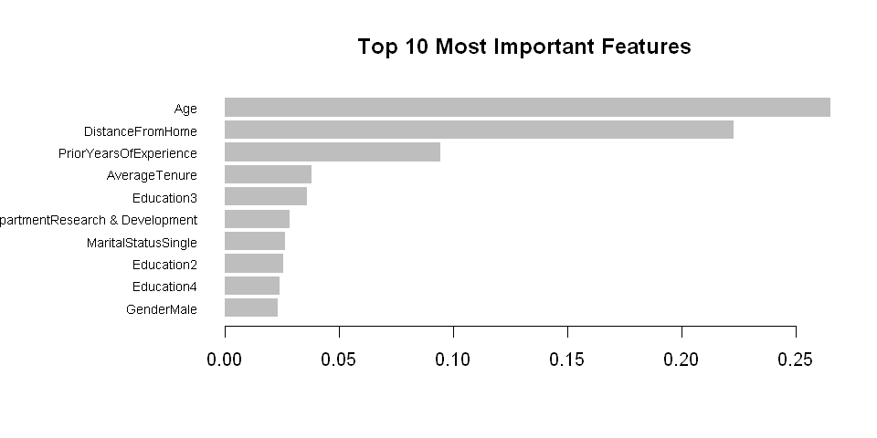

```r
# Plot most important features
xgb.plot.importance(importance_matrix = importance, top_n = 10, main = "Top 10 Most Important Features")
```

```r
# Run a "Chi-Squared Goodness of Fit Test" to make sure those highly ranked variables are indeed meaningful for the model
# Looking for a p-value of less than 0.05 to confirm the variables are significant
# As well as an chi-squared (x-squared) value above 5 to confirm the test's validity
c2 <- chisq.test(data_hr_1$Age, output_vector)
print(c2)

c2 <- chisq.test(data_hr_1$DistanceFromHome, output_vector)
print(c2)

c2 <- chisq.test(data_hr_1$PriorYearsOfExperience, output_vector)
print(c2)

c2 <- chisq.test(data_hr_1$AverageTenure, output_vector)
print(c2)

c2 <- chisq.test(data_hr_1$Education, output_vector)
print(c2)

c2 <- chisq.test(data_hr_1$Department, output_vector)
print(c2)

c2 <- chisq.test(data_hr_1$MaritalStatus, output_vector)
print(c2)
```

```
	Pearson's Chi-squared test

data:  data_hr_1$Age and output_vector
X-squared = 1823.6, df = 42, p-value < 2.2e-16


	Pearson's Chi-squared test

data:  data_hr_1$DistanceFromHome and output_vector
X-squared = 564.63, df = 28, p-value < 2.2e-16
```

```
	Pearson's Chi-squared test

data:  data_hr_1$PriorYearsOfExperience and output_vector
X-squared = 211.03, df = 35, p-value < 2.2e-16
```

```
	Pearson's Chi-squared test

data:  data_hr_1$AverageTenure and output_vector
X-squared = 565.52, df = 155, p-value < 2.2e-16


	Pearson's Chi-squared test

data:  data_hr_1$Education and output_vector
X-squared = 42.616, df = 4, p-value = 1.243e-08


	Pearson's Chi-squared test

data:  data_hr_1$Department and output_vector
X-squared = 167.9, df = 2, p-value < 2.2e-16


	Pearson's Chi-squared test

data:  data_hr_1$MaritalStatus and output_vector
X-squared = 380.58, df = 2, p-value < 2.2e-16
```

### Conclusion

> All our p-values are much lower than 0.05, meaning we've found our most significant variables (among those available at hiring time) in predicting employee resignation!

> Among those, the GLM tells us that the variables correlated with staying are Age (older is more likely to stay), AverageTenure (longer predicts staying), and Department (those hired at the Research and Development department are more likely to stay). While increases in YearsOfExperience are predictors of greater likelihood of employee resignation, as is any MaritalStatus other than divorced, and a longer DistanceFromHome.

> Additionally, XGBoost also ranks Education (2, 3 and 4) as important, while GLM adds JobRole (Manager, Research Director, Laboratory Technician or Sales Representative) and EmployeeSource (Company Website).

> The insights generated during both exploratory analysis and predictive modeling we can now be shared with IBM's HR department as we team up to reduce employee resignation and turnover!

# End

Matheus Schmitz

[LinkedIn](https://www.linkedin.com/in/matheusschmitz/)

[Github Portfolio](https://matheus-schmitz.github.io/)